# Practica Final Modelos Supervisados-5

## Práctica Final

#### Borja Casasnovas y Jaime Uhagon

#### Librerias

```python
import numpy as np
import pandas as pd
import matplotlib.pyplot as plt
import seaborn as sns
import seaborn as sb
from sklearn.datasets import load_digits
from sklearn import linear_model
from sklearn import model_selection
from sklearn.metrics import classification_report
from sklearn.metrics import confusion_matrix
from sklearn.metrics import accuracy_score
%matplotlib inline
import warnings
warnings.filterwarnings('ignore')
from sklearn.datasets import make_classification
from sklearn.ensemble import RandomForestClassifier
from sklearn.calibration import calibration_curve
from sklearn.calibration import CalibratedClassifierCV
from sklearn.metrics import brier_score_loss
from sklearn.metrics import classification_report
import warnings
warnings.filterwarnings('once')
warnings.simplefilter('ignore', (DeprecationWarning))
```

```python
pd.options.display.max_rows = 5
```

```python
Airbnb = '/Users/borjacasasnovas/Desktop/Modelos Supervisados/Práctica 2/airbnb-listings-extract.csv'

Airbnb = pd.read_csv(Airbnb, header=0, sep=';')
```

```python
airbnb = Airbnb
airbnb = airbnb.set_index(['ID'])

#airbnb = airbnb.set_index(['ID','Name'])
airbnb = airbnb.drop(['Name','Listing Url', 'Scrape ID','Last Scraped','Summary','Thumbnail Url','Medium Url',
               'Picture Url','XL Picture Url','Host ID','Host URL','Host Name','Host Since','Host Location',
               'Host About','Host Thumbnail Url','Host Picture Url','Host Neighbourhood',
               'Neighbourhood','Neighbourhood Cleansed','State','Zipcode','Market','City','Country Code',
               'Country','Latitude','Longitude', 'Amenities','Calendar last Scraped','First Review','Last Review',
               'License','Jurisdiction Names','Geolocation','Host Verifications',
                      'Neighbourhood Group Cleansed','Space', 'Description', 'Neighborhood Overview', 'Notes','Transit',
                      'Access', 'Interaction','House Rules','Street','Smart Location','Features'], axis = 1)
```

A summary y a Space no les aplicaremos Descrpition transform porque tienen informacion parecida, pero no esta bien puesta. Es decir, para una primera variable description describe la casa de cierta manera y space de otra, para una segunda variable, mientras description la describe de una manera diferente a la de la primera, space describe la segunda variable como description la primera. Por tanto, al no estar claro, no se les aplicara el algoritmo descprition transform.

'Host Acceptance Rate' y 'Square Feet' son columnas sin información, por eso lo quitamos.

Space, Description, Neighborhood Overview, Notes,Transit, Access, Interaction, House Rules

#### Limpieza de datos

Creamos un dataframe nuevo para visualizar lo que queremos hacer y posteriormente ejecutarlo sobre el que queremos trabajar (airbnb)

```python
pd.options.display.max_rows = 10
```

```
Experiences Offered                   0
Host Response Time                 1899
Host Response Rate                 1899
Host Acceptance Rate              14741
Host Listings Count                   3
                                  ...
Review Scores Location             3340
Review Scores Value                3341
Cancellation Policy                   0
Calculated host listings count        4
Reviews per Month                  3162
Length: 40, dtype: int64
```

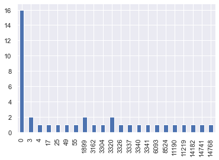

```python
CountNA = airbnb.isna().sum()
print(CountNA)
CountNA.groupby(CountNA.values).count().plot.bar()
```

Podemos observar graficamente la distribucion de los NAs segunn el numero de ellos que haya en cada variable. Con esto podemos observar que habra 16 variables que no tienen ningun NA o por ejemplo 2 variables que tiene 1899 NAs entre sus valores. Nos da una idea clara del numero de valores missing que hay en cada variable para luego saber como sustituir cada valor.

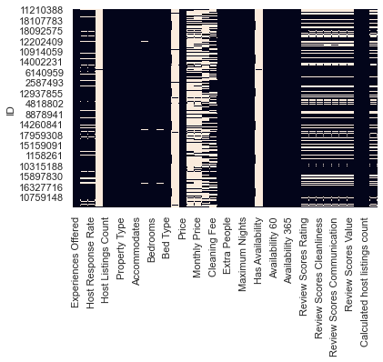

```python
sns.heatmap(airbnb.isnull(), cbar=False)
```

Con esta grafica observamos de manera visual en un plano 2D donde se hayan los NAs

```python
100*airbnb['Square Feet'].isna().sum()/airbnb.shape[0]
```

```
95.95399188092016
```

```python
for col in airbnb.columns:
    if sum(airbnb[col].isnull())/float(len(airbnb.index)) > 0.60: del airbnb[col]
```

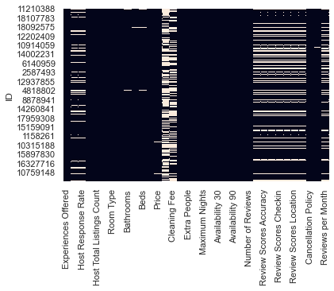

```python
sns.heatmap(airbnb.isnull(), cbar=False)
```

```python
pd.options.display.max_rows = 50
```

```python
100*airbnb.isna().sum()/airbnb.shape[0]
```

```
Experiences Offered                0.000000
Host Response Time                12.848444
Host Response Rate                12.848444
Host Listings Count                0.020298
Host Total Listings Count          0.020298
Property Type                      0.000000
Room Type                          0.000000
Accommodates                       0.000000
Bathrooms                          0.372124
Bedrooms                           0.169147
Beds                               0.331529
Bed Type                           0.000000
Price                              0.115020
Security Deposit                  57.672530
Cleaning Fee                      41.224628
Guests Included                    0.000000
Extra People                       0.000000
Minimum Nights                     0.000000
Maximum Nights                     0.000000
Calendar Updated                   0.000000
Availability 30                    0.000000
Availability 60                    0.000000
Availability 90                    0.000000
Availability 365                   0.000000
Number of Reviews                  0.000000
Review Scores Rating              22.354533
Review Scores Accuracy            22.503383
Review Scores Cleanliness         22.462788
Review Scores Checkin             22.577808
Review Scores Communication       22.462788
Review Scores Location            22.598106
Review Scores Value               22.604871
Cancellation Policy                0.000000
Calculated host listings count     0.027064
Reviews per Month                 21.393775
dtype: float64
```

En esta tabla hemos calculado la proporcion de valores missing que hay por cada variable, sobre el total de todos los datos. Hay dos variables que detacan por encima del resto que son "Security Deposit" y "Cleaning Fee", con un 57% y 41% respectivamente. El resto estan completas en un gran porcentaje.

```
Experiences Offered                object
Host Response Time                 object
Host Response Rate                float64
Host Listings Count               float64
Host Total Listings Count         float64
Property Type                      object
Room Type                          object
Accommodates                        int64
Bathrooms                         float64
Bedrooms                          float64
Beds                              float64
Bed Type                           object
Price                             float64
Security Deposit                  float64
Cleaning Fee                      float64
Guests Included                     int64
Extra People                        int64
Minimum Nights                      int64
Maximum Nights                      int64
Calendar Updated                   object
Availability 30                     int64
Availability 60                     int64
Availability 90                     int64
Availability 365                    int64
Number of Reviews                   int64
Review Scores Rating              float64
Review Scores Accuracy            float64
Review Scores Cleanliness         float64
Review Scores Checkin             float64
Review Scores Communication       float64
Review Scores Location            float64
Review Scores Value               float64
Cancellation Policy                object
Calculated host listings count    float64
Reviews per Month                 float64
dtype: object
```

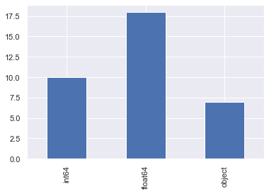

```python
data_types = airbnb.dtypes
print(data_types)
data_types.groupby(data_types.values).count().plot.bar()
```

```python
cat_features = airbnb.dtypes[airbnb.dtypes == 'object'].index.to_list()
num_features = airbnb.dtypes[airbnb.dtypes != 'object'].index.to_list()
```

Dividimos las variables entre enumericas y categoricas ya que mas adelante seran tratadas de diferente forma por su condicion

```python
cat_features
```

```
['Experiences Offered',
 'Host Response Time',
 'Property Type',
 'Room Type',
 'Bed Type',
 'Calendar Updated',
 'Cancellation Policy']
```

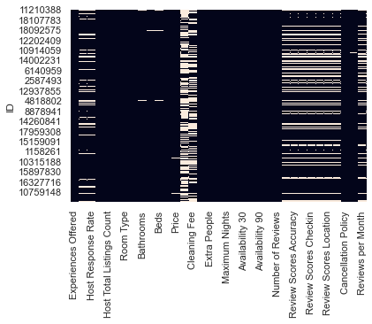

```python
sns.heatmap(airbnb.isnull(), cbar=False)
```

```python
airbnb[cat_features].isna().sum()
```

```
Experiences Offered       0
Host Response Time     1899
Property Type             0
Room Type                 0
Bed Type                  0
Calendar Updated          0
Cancellation Policy       0
dtype: int64
```

```python
airbnb[num_features] = airbnb[num_features].fillna(airbnb[num_features].mean())
```

```python
airbnb[cat_features] = airbnb[cat_features].fillna(0)
```

Como ya hemos cometado antes, las variables son tratadas de diferente manera por su condicion. En este caso, las variables numericas que contengan NAs veran como sus valores missing seran sustituidos por la media de la variable. A la contra, en las variables categoricas, seran sustituidos por ceros.

```python
from category_encoders.one_hot import OneHotEncoder
coder = OneHotEncoder()
coder.fit(airbnb[cat_features])
Dummies = pd.DataFrame(coder.transform(airbnb[cat_features]))
Dummies
```

| ID | Experiences Offered_1 | Experiences Offered_2 | Experiences Offered_3 | Experiences Offered_4 | Experiences Offered_5 | Host Response Time_1 | Host Response Time_2 | Host Response Time_3 | Host Response Time_4 | Host Response Time_5 | ... | Calendar Updated_56 | Calendar Updated_57 | Cancellation Policy_1 | Cancellation Policy_2 | Cancellation Policy_3 | Cancellation Policy_4 | Cancellation Policy_5 | Cancellation Policy_6 | Cancellation Policy_7 | Cancellation Policy_8 |
| --- | --- | --- | --- | --- | --- | --- | --- | --- | --- | --- | --- | --- | --- | --- | --- | --- | --- | --- | --- | --- | --- |
| 11210388 | 1 | 0 | 0 | 0 | 0 | 1 | 0 | 0 | 0 | 0 | ... | 0 | 0 | 1 | 0 | 0 | 0 | 0 | 0 | 0 | 0 |
| 17471131 | 1 | 0 | 0 | 0 | 0 | 1 | 0 | 0 | 0 | 0 | ... | 0 | 0 | 0 | 1 | 0 | 0 | 0 | 0 | 0 | 0 |
| 17584891 | 1 | 0 | 0 | 0 | 0 | 1 | 0 | 0 | 0 | 0 | ... | 0 | 0 | 0 | 1 | 0 | 0 | 0 | 0 | 0 | 0 |
| 5398030 | 1 | 0 | 0 | 0 | 0 | 1 | 0 | 0 | 0 | 0 | ... | 0 | 0 | 0 | 0 | 1 | 0 | 0 | 0 | 0 | 0 |
| 18104606 | 1 | 0 | 0 | 0 | 0 | 1 | 0 | 0 | 0 | 0 | ... | 0 | 0 | 0 | 0 | 0 | 1 | 0 | 0 | 0 | 0 |
| ... | ... | ... | ... | ... | ... | ... | ... | ... | ... | ... | ... | ... | ... | ... | ... | ... | ... | ... | ... | ... | ... |
| 2098030 | 1 | 0 | 0 | 0 | 0 | 0 | 0 | 1 | 0 | 0 | ... | 0 | 0 | 0 | 0 | 1 | 0 | 0 | 0 | 0 | 0 |
| 17989442 | 1 | 0 | 0 | 0 | 0 | 0 | 0 | 0 | 1 | 0 | ... | 0 | 0 | 0 | 0 | 0 | 1 | 0 | 0 | 0 | 0 |
| 13278634 | 1 | 0 | 0 | 0 | 0 | 1 | 0 | 0 | 0 | 0 | ... | 0 | 0 | 0 | 0 | 1 | 0 | 0 | 0 | 0 | 0 |
| 10733941 | 1 | 0 | 0 | 0 | 0 | 0 | 0 | 1 | 0 | 0 | ... | 0 | 0 | 1 | 0 | 0 | 0 | 0 | 0 | 0 | 0 |
| 4637801 | 1 | 0 | 0 | 0 | 0 | 1 | 0 | 0 | 0 | 0 | ... | 0 | 0 | 0 | 0 | 0 | 1 | 0 | 0 | 0 | 0 |

14780 rows × 105 columns

Lo cometado anteriormente cobra sentido cuando creamos dummies de las variables categoricas, si sustituimos por la media, los valores missing pasarian a tener valores decimales, lo cual no tiene sentido tratandose de variables categoricas, que tienen que contener solo numeros enteros despues de su transformacion con dummies.

```python
final=airbnb.join(Dummies)
Airbnb_ft = final.drop(cat_features, axis = 1)
```

```python
Airbnb_ft.shape
```

```
(14780, 133)
```

```python
Airbnb_ft.describe()
```

|  | Host Response Rate | Host Listings Count | Host Total Listings Count | Accommodates | Bathrooms | Bedrooms | Beds | Price | Security Deposit | Cleaning Fee | ... | Calendar Updated_56 | Calendar Updated_57 | Cancellation Policy_1 | Cancellation Policy_2 | Cancellation Policy_3 | Cancellation Policy_4 | Cancellation Policy_5 | Cancellation Policy_6 | Cancellation Policy_7 | Cancellation Policy_8 |
| --- | --- | --- | --- | --- | --- | --- | --- | --- | --- | --- | --- | --- | --- | --- | --- | --- | --- | --- | --- | --- | --- |
| count | 14780.000000 | 14780.000000 | 14780.000000 | 14780.000000 | 14780.000000 | 14780.000000 | 14780.000000 | 14780.000000 | 14780.000000 | 14780.000000 | ... | 14780.000000 | 14780.000000 | 14780.000000 | 14780.000000 | 14780.000000 | 14780.000000 | 14780.000000 | 14780.000000 | 14780.000000 | 14780.000000 |
| mean | 94.823461 | 12.513636 | 12.513636 | 3.277808 | 1.281732 | 1.343816 | 2.044260 | 73.561471 | 189.226822 | 31.805341 | ... | 0.000068 | 0.000068 | 0.287415 | 0.001286 | 0.388498 | 0.316035 | 0.000947 | 0.002165 | 0.002300 | 0.001353 |
| std | 14.204814 | 34.086763 | 34.086763 | 2.097291 | 0.657291 | 0.899317 | 1.610094 | 72.020593 | 74.913332 | 23.672547 | ... | 0.008226 | 0.008226 | 0.452572 | 0.035832 | 0.487425 | 0.464943 | 0.030763 | 0.046482 | 0.047909 | 0.036762 |
| min | 0.000000 | 0.000000 | 0.000000 | 1.000000 | 0.000000 | 0.000000 | 1.000000 | 9.000000 | 0.000000 | 0.000000 | ... | 0.000000 | 0.000000 | 0.000000 | 0.000000 | 0.000000 | 0.000000 | 0.000000 | 0.000000 | 0.000000 | 0.000000 |
| 25% | 94.823461 | 1.000000 | 1.000000 | 2.000000 | 1.000000 | 1.000000 | 1.000000 | 34.000000 | 189.226822 | 20.000000 | ... | 0.000000 | 0.000000 | 0.000000 | 0.000000 | 0.000000 | 0.000000 | 0.000000 | 0.000000 | 0.000000 | 0.000000 |
| 50% | 100.000000 | 2.000000 | 2.000000 | 3.000000 | 1.000000 | 1.000000 | 2.000000 | 55.000000 | 189.226822 | 31.805341 | ... | 0.000000 | 0.000000 | 0.000000 | 0.000000 | 0.000000 | 0.000000 | 0.000000 | 0.000000 | 0.000000 | 0.000000 |
| 75% | 100.000000 | 6.000000 | 6.000000 | 4.000000 | 1.000000 | 2.000000 | 2.000000 | 86.000000 | 189.226822 | 31.805341 | ... | 0.000000 | 0.000000 | 1.000000 | 0.000000 | 1.000000 | 1.000000 | 0.000000 | 0.000000 | 0.000000 | 0.000000 |
| max | 100.000000 | 519.000000 | 519.000000 | 16.000000 | 8.000000 | 10.000000 | 16.000000 | 999.000000 | 990.000000 | 662.000000 | ... | 1.000000 | 1.000000 | 1.000000 | 1.000000 | 1.000000 | 1.000000 | 1.000000 | 1.000000 | 1.000000 | 1.000000 |

8 rows × 133 columns

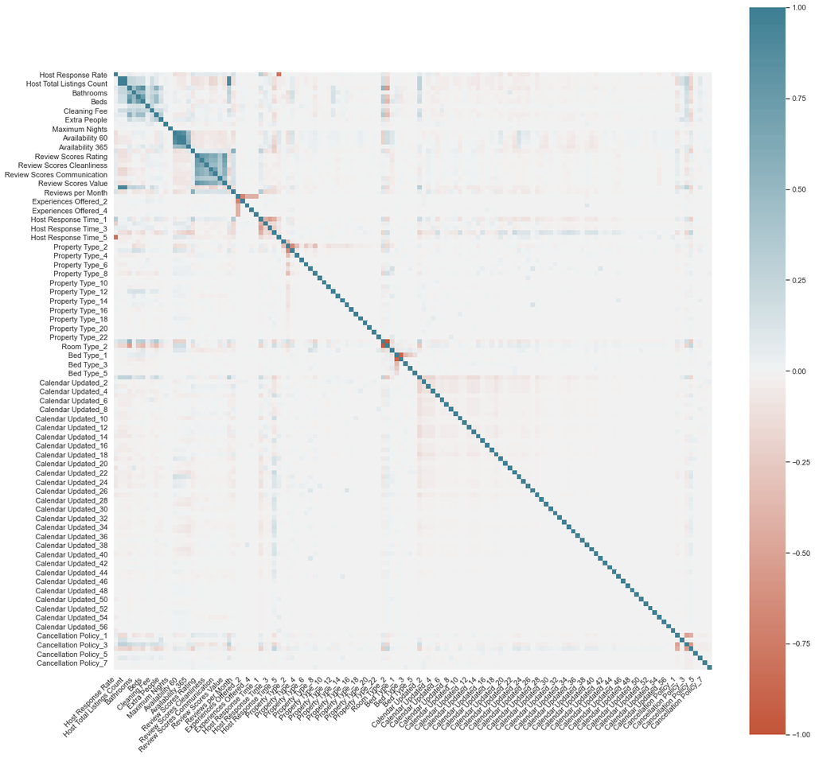

```python
Correlation = Airbnb_ft.drop(['Price'], axis = 1)

sns.set(rc = {'figure.figsize':(20,20)})


corr = Correlation.corr()
ax = sns.heatmap(
    corr,
    vmin=-1, vmax=1, center=0,
    cmap=sns.diverging_palette(20, 220, n=200),
    square=True
)
ax.set_xticklabels(
    ax.get_xticklabels(),
    rotation=45,
    horizontalalignment='right'
);
```

En este diagrama de correlacion observamos si los comportamientos de las variables son parecidos y si siguen las mismas tendencias. En las primeras variables si hay correlaciones, por ejemplo a mayor numero de habitaciones, mayor numero de baños o a mejores reseñas generales, mejores reseñas de limpieza. Nada es sorprendente, ya que son variables que van de la mano, ya sea por la logica en la arquitectura (mayores casas tienen mas cuartos y por lo tanto mas baños) o al ser alguna variable parte de otra (dentro de la reseña general, se puntua tambien la limpieza)

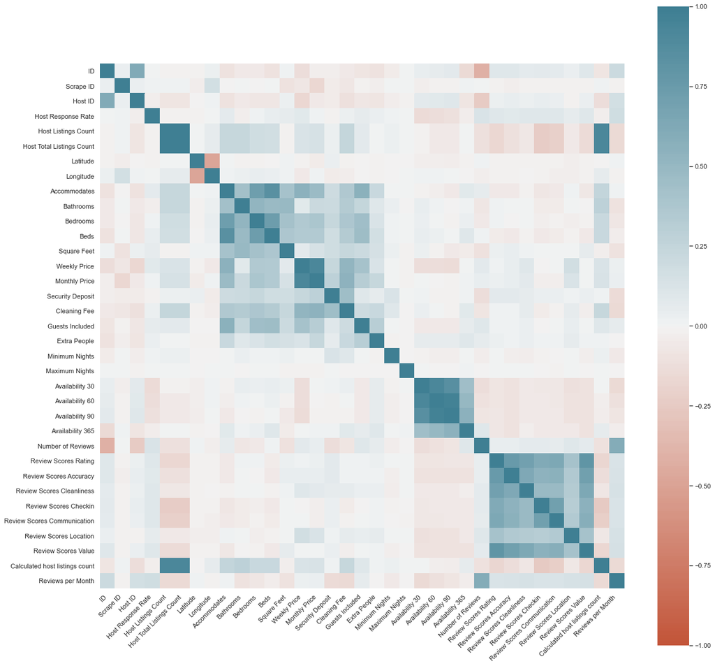

```python
Correlation = Airbnb.drop(['Price'], axis = 1)

sns.set(rc = {'figure.figsize':(20,20)})


corr = Correlation.corr()
ax = sns.heatmap(
    corr,
    vmin=-1, vmax=1, center=0,
    cmap=sns.diverging_palette(20, 220, n=200),
    square=True
)
ax.set_xticklabels(
    ax.get_xticklabels(),
    rotation=45,
    horizontalalignment='right'
);
```

Para hacerlo mas facil, buscaremos correlaciones fuertes en el data frame sin dummies. Podemos eliminar Availability in 30 & Availability in 60, y dejaremos Availability in 90 days que nos aporta la misma información. Tambien eliminaremos Host Listings Count y nos quedaremos con Host Total Listing Count, que nos aporta lo mismo.

En el data frame con dummies observamos que los bed types se correlcionan bastante, sin embargo, como no tenemos del todo claro si son bed types, porque los cuadrados son muy pequeños como para diferenciar quien va con quien, no los eliminaremos.

Observamos con mas claridad otro tipo de corrlaciones que ya habiamos percibido. Elprimer grupo con variables correlcionadas tiene que ver con el tamaño de la casa. El numero de integrantes, el numero de habitaciones, el numero de baños, el numero de camas, los metros cuadrados, etc. son todo variables que al aumentar los inquilinos deben aumentar por logica.

```python
Airbnb_ft = Airbnb_ft.drop(['Availability 30','Availability 60','Host Listings Count'], axis = 1)
```

```python
Airbnb_ft.shape
```

```
(14780, 130)
```

De la grafica superior, observar si podemos/ debemos quitar las variables menos correlacionadas con Price

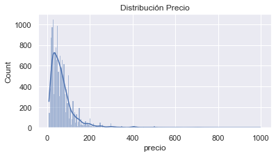

```python
fig, ax = plt.subplots(nrows=1, ncols=1, figsize=(6, 3))
sns.histplot(data=Airbnb_ft, x='Price', kde=True,ax=ax)
ax.set_title("Distribución Precio")
ax.set_xlabel('precio');
```

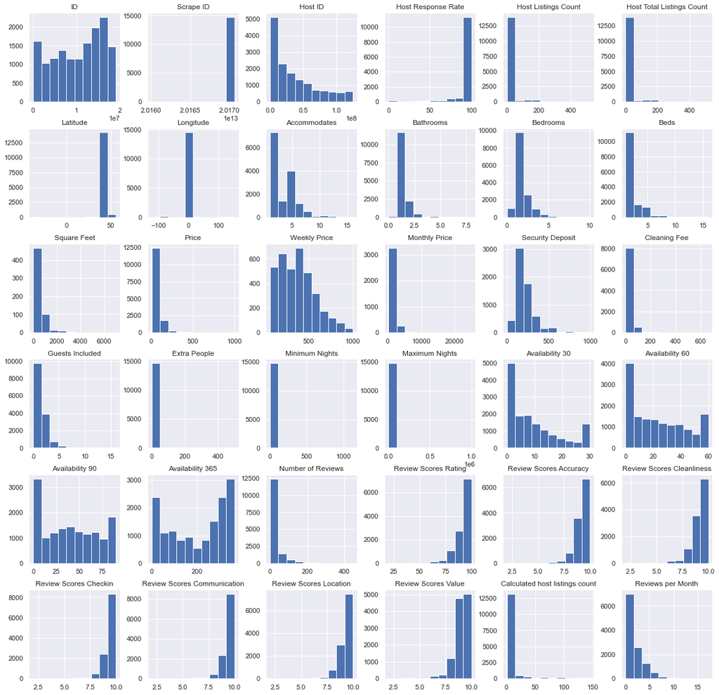

```python
Airbnb.hist()
plt.show()
```

En estos graficos vemos la distribucion de los valores agrupados por variables. Nos hace tener una idea rapida de los intervalos en los que se mueven las variables y distinguir a priori donde se encuentran las medias y las madianas. Podemos ver entre que rangos se encuentran los precios, el numero de habitaciones, los ratings, o la disponibilidad que ofrecen.

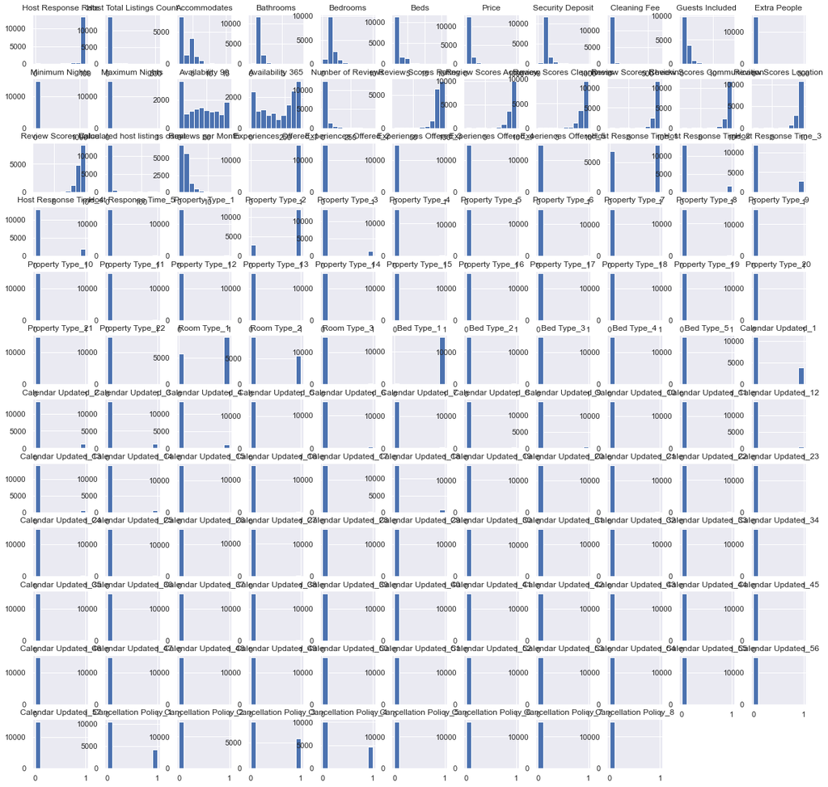

```python
Airbnb_ft.hist()
plt.show()
```

```python
Airbnb_ft['Price'].describe()
```

```
count    14780.000000
mean        73.561471
std         72.020593
min          9.000000
25%         34.000000
50%         55.000000
75%         86.000000
max        999.000000
Name: Price, dtype: float64
```

Eliminamos posibles outliers

```python
Airbnb_ft = Airbnb_ft[(airbnb['Price'] <= 100)]
```

### Aplicación de Modelos

Separación y entrenamiento

```python
from sklearn.model_selection import train_test_split


Air_train, Air_test = train_test_split(Airbnb_ft, test_size = 0.3, stratify = Airbnb_ft["Price"])
```

```python
from sklearn.preprocessing import StandardScaler

std_scaler = StandardScaler()
train_scaler = std_scaler.fit(Air_train)


std_scaler

Air_train_normalized = pd.DataFrame(std_scaler.fit_transform(Air_train.values), columns=Air_train.columns)
```

```python
Air_train_normalized = pd.DataFrame(Air_train_normalized, index=Air_train.index, columns=Air_train.columns)
```

```python
X_norm = np.array(Air_train_normalized.drop(['Price'],axis = 1))
X = np.array(Air_train.drop(['Price'],axis = 1))


y = np.array(Air_train['Price'])
```

```python
from sklearn.preprocessing import StandardScaler

Airbnb_test_normalized = pd.DataFrame(std_scaler.transform(Air_test), columns=Air_test.columns)
```

```python
Airbnb_test_normalized = pd.DataFrame(Airbnb_test_normalized, index=Air_test.index, columns=Air_test.columns)
```

```python
test_x_norm = np.array(Airbnb_test_normalized.drop(['Price'],axis = 1))
test_x = np.array(Air_test.drop(['Price'],axis = 1))


#test_y = np.array(Airbnb_test_normalized['Price'])
test_y = np.array(Air_test['Price'])
```

Vamos a tratar de resolver predecir los resultados con ciertos modelos. Nos basaremos para compararar que modelo es mejor en mean square error. El objetivo es comparar que modelo dispone de menor MSE para poder hacer uso de dicho modelo y predecir.

Para manejar los modelos tratarmeos de optimizar dichos modelos, esto es calibar el modelo a nuestro antojo para, supuestamente, obtener mejores resultados.

Calibrar un modelo consiste en corregir las desviaciones de su curva de calibrado respecto a la diagonal (considerada la calibración perfecta). Esto puede conseguirse con un segundo modelo que aprenda como hacer la corrección. Los modelos empleados para esta corrección suelen ser regresión logística (platt scaling) o regresión isotónica. La regresión isotónica solo se recomienda cuando se dispone de >1000 observaciones, por su facilidad de overfitting.

El entrenamiento del modelo correctivo no debe hacerse con los mismos datos con los que se ha entrenado el modelo principal para evitar así el overfitting. En su lugar, se debe utilizar un conjunto de validación o validación cruzada.

### Regresión Lineal

#### Entrenamiento

```python
lr = linear_model.LinearRegression(normalize=False)
```

```python
lr.fit(X,y)
```

```
LinearRegression()
```

```python
lr.score(X,y)
```

```
0.5860170500408156
```

#### Evaluación

```python
predictions = lr.predict(test_x)
```

```python
R_2 = lr.score(test_x,test_y)
R_2
```

```
0.5957490666954404
```

```python
predicted_data_norm = Airbnb_test_normalized.copy()
predicted_data_norm['Price'] = predictions
```

```python
predicted_data_unorm = pd.DataFrame(index=predicted_data_norm.index,
                                    columns=predicted_data_norm.columns,
                                    data=train_scaler.inverse_transform(predicted_data_norm))
```

```python
 predicted_data_unorm['predicted_price'] = predicted_data_unorm['Price']
```

```python
predicted_data_unorm['Price'] = Air_test['Price']
```

```python
predicted_data_unorm['Price']
```

```
ID
5895915     55.0
598771      85.0
11018241    82.0
16927272    60.0
1343630     32.0
            ...
8436621     27.0
675713      65.0
17960977    52.0
12032647    46.0
18004441    25.0
Name: Price, Length: 3698, dtype: float64
```

```python
predicted_data_unorm[['Price','predicted_price']].head(3)
```

| ID | Price | predicted_price |
| --- | --- | --- |
| 5895915 | 55.0 | 1442.960538 |
| 598771 | 85.0 | 1808.464205 |
| 11018241 | 82.0 | 1772.621433 |

```python
rmse_linear = np.sqrt(((predicted_data_unorm['Price'] - predicted_data_unorm['predicted_price'])**2).mean())
```

```python
rmse_linear
```

```
1305.1117472542453
```

```python
from sklearn.metrics import mean_squared_error
mean_squared_error(predicted_data_unorm['Price'], predicted_data_unorm['predicted_price'], squared=False)
```

```
1305.1117472542455
```

```python
lr_error = round(np.mean(100*np.sqrt((predicted_data_unorm['Price'] - predicted_data_unorm['predicted_price'])**2)/predicted_data_unorm['Price']),2)
lr_error
```

```
2741.68
```

```python
lr.get_params().keys()
```

[output not shown]

Calibrar un modelo consiste en corregir las desviaciones de su curva de calibrado respecto a la diagonal (calibración perfecta). Esto puede conseguirse con un segundo modelo que aprenda como hacer la corrección. Los modelos empleados para esta corrección suelen ser regresión logística (platt scaling) o regresión isotónica. La regresión isotónica solo se recomienda cuando se dispone de >1000 observaciones, por su facilidad de overfitting.

El entrenamiento del modelo correctivo no debe hacerse con los mismos datos con los que se ha entrenado el modelo principal para evitar así el overfitting. En su lugar, se debe utilizar un conjunto de validación o validación cruzada.

### Gradien Boost

```python
from sklearn.ensemble import GradientBoostingRegressor
```

```python
boost = GradientBoostingRegressor()
boost.fit(X, y)
boost.score(X, y)
```

```
0.6749761482574321
```

```python
boost.score(test_x, test_y)
```

```
0.6703982012979652
```

```python
rmse_gboost = mean_squared_error(test_y,
                                 boost.predict(test_x), squared=False)
```

```python
rmse_gboost
```

```
13.834005412490045
```

```python
gboost_error = round(np.mean(100*np.sqrt((test_y - boost.predict(test_x))**2)/test_y),2)
gboost_error
```

```
25.48
```

```python
boost.feature_importances_
```

```
array([2.28743942e-04, 1.13778998e-02, 6.43442803e-02, 1.30958663e-02,
       1.46732743e-02, 3.61360685e-03, 9.66995274e-03, 4.49301839e-02,
       1.21550810e-02, 3.44664098e-02, 5.84849670e-03, 5.64977333e-04,
       8.35768047e-03, 5.46707583e-03, 8.18151668e-04, 1.14322502e-02,
       1.45505175e-03, 2.08277663e-03, 1.52389912e-04, 0.00000000e+00,
       2.66106976e-02, 6.91999311e-04, 4.59168417e-03, 9.48222313e-03,
       0.00000000e+00, 0.00000000e+00, 0.00000000e+00, 0.00000000e+00,
       0.00000000e+00, 1.65435403e-04, 6.72791328e-05, 0.00000000e+00,
       3.64401967e-03, 0.00000000e+00, 2.84163397e-04, 0.00000000e+00,
       5.58406564e-06, 0.00000000e+00, 0.00000000e+00, 9.33599274e-05,
       0.00000000e+00, 0.00000000e+00, 0.00000000e+00, 3.14113433e-04,
       8.07837999e-05, 0.00000000e+00, 0.00000000e+00, 0.00000000e+00,
       0.00000000e+00, 3.97917425e-04, 5.59086788e-04, 0.00000000e+00,
       0.00000000e+00, 0.00000000e+00, 0.00000000e+00, 0.00000000e+00,
       6.95238304e-01, 3.81717016e-04, 4.71602489e-03, 2.92549808e-04,
       2.68455810e-04, 0.00000000e+00, 0.00000000e+00, 0.00000000e+00,
       2.82670588e-04, 0.00000000e+00, 8.77346726e-05, 0.00000000e+00,
       0.00000000e+00, 7.05980263e-04, 0.00000000e+00, 0.00000000e+00,
       8.16206193e-04, 1.58117619e-04, 0.00000000e+00, 0.00000000e+00,
       0.00000000e+00, 7.90797581e-05, 0.00000000e+00, 0.00000000e+00,
       3.95391242e-04, 0.00000000e+00, 0.00000000e+00, 2.09805493e-04,
       0.00000000e+00, 1.16716213e-04, 0.00000000e+00, 0.00000000e+00,
       7.22592868e-05, 0.00000000e+00, 0.00000000e+00, 0.00000000e+00,
       0.00000000e+00, 0.00000000e+00, 4.53915062e-04, 0.00000000e+00,
       0.00000000e+00, 1.04659244e-04, 0.00000000e+00, 0.00000000e+00,
       0.00000000e+00, 0.00000000e+00, 0.00000000e+00, 2.13873672e-04,
       0.00000000e+00, 0.00000000e+00, 0.00000000e+00, 5.80213774e-04,
       2.91157549e-04, 0.00000000e+00, 0.00000000e+00, 0.00000000e+00,
       0.00000000e+00, 0.00000000e+00, 0.00000000e+00, 0.00000000e+00,
       3.29675666e-04, 0.00000000e+00, 0.00000000e+00, 0.00000000e+00,
       0.00000000e+00, 5.79412959e-04, 0.00000000e+00, 5.46071097e-04,
       9.19462789e-04, 0.00000000e+00, 0.00000000e+00, 0.00000000e+00,
       4.38048354e-04])
```

```python
features = [(a,b) for a,b in zip(Air_train.columns, boost.feature_importances_)]
```

```python
features = sorted(features, key= lambda c:c[1], reverse=True)
```

```python
features
```

```
[('Property Type_22', 0.6952383043699057),
 ('Accommodates', 0.06434428031174022),
 ('Security Deposit', 0.04493018394382718),
 ('Guests Included', 0.03446640978991281),
 ('Review Scores Communication', 0.02661069759658394),
 ('Bedrooms', 0.014673274254271227),
 ('Bathrooms', 0.01309586626494999),
 ('Cleaning Fee', 0.012155080957491394),
 ('Number of Reviews', 0.011432250227243031),
 ('Host Total Listings Count', 0.011377899773685378),
 ('Price', 0.009669952741193694),
 ('Calculated host listings count', 0.009482223134775909),
 ('Maximum Nights', 0.008357680471849658),
 ('Extra People', 0.005848496704630549),
 ('Availability 90', 0.005467075827847204),
 ('Room Type_2', 0.004716024891554617),
 ('Review Scores Value', 0.004591684167442462),
 ('Host Response Time_3', 0.003644019671640201),
 ('Beds', 0.00361360684647765),
 ('Review Scores Accuracy', 0.002082776633715405),
 ('Review Scores Rating', 0.0014550517537606528),
 ('Cancellation Policy_3', 0.0009194627894159322),
 ('Availability 365', 0.0008181516680766352),
 ('Calendar Updated_8', 0.0008162061926500748),
 ('Calendar Updated_5', 0.000705980263258283),
 ('Review Scores Location', 0.0006919993105546076),
 ('Calendar Updated_43', 0.000580213774338859),
 ('Calendar Updated_57', 0.0005794129591592933),
 ('Minimum Nights', 0.000564977332621832),
 ('Property Type_16', 0.0005590867879097356),
 ('Cancellation Policy_2', 0.0005460710967547729),
 ('Calendar Updated_30', 0.00045391506239462933),
 ('Cancellation Policy_7', 0.00043804835358342655),
 ('Property Type_15', 0.00039791742474269416),
 ('Calendar Updated_16', 0.0003953912424599859),
 ('Room Type_1', 0.00038171701553696153),
 ('Calendar Updated_52', 0.00032967566568646014),
 ('Property Type_9', 0.0003141134330321914),
 ('Room Type_3', 0.00029254980801114825),
 ('Calendar Updated_44', 0.00029115754935917756),
```

[output cut: 74 more lines]

```
 ('Calendar Updated_45', 0.0),
 ('Calendar Updated_46', 0.0),
 ('Calendar Updated_47', 0.0),
 ('Calendar Updated_48', 0.0),
 ('Calendar Updated_49', 0.0),
 ('Calendar Updated_50', 0.0),
 ('Calendar Updated_51', 0.0),
 ('Calendar Updated_53', 0.0),
 ('Calendar Updated_54', 0.0),
 ('Calendar Updated_55', 0.0),
 ('Calendar Updated_56', 0.0),
 ('Cancellation Policy_1', 0.0),
 ('Cancellation Policy_4', 0.0),
 ('Cancellation Policy_5', 0.0),
 ('Cancellation Policy_6', 0.0)]
```

### Hiperparametros

```python
from sklearn.model_selection import RandomizedSearchCV
import multiprocessing


parameters = ({'learning_rate':[0.01, 0.1],
               'n_estimators': [200, 100],
               'subsample': [1, 0.7],
               'min_samples_split': [2, 4]})


# Aplicamos la tecnica de validación cruzada

grid = RandomizedSearchCV(
        estimator  = boost,
        param_distributions = parameters,
        n_iter     = 50,
        scoring    = 'neg_mean_squared_error',
        n_jobs     = multiprocessing.cpu_count() - 1,
        cv         = 5,
        verbose    = 0,
        random_state = 123,
        return_train_score = True
       )

grid.fit(X = X, y = y)


resultados = pd.DataFrame(grid.cv_results_)
resultados.filter(regex = '(param.*|mean_t|std_t)')\
    .drop(columns = 'params')\
    .sort_values('mean_test_score', ascending = False)\
    .head(10)
```

|  | param_subsample | param_n_estimators | param_min_samples_split | param_learning_rate | mean_test_score | std_test_score | mean_train_score | std_train_score |
| --- | --- | --- | --- | --- | --- | --- | --- | --- |
| 13 | 0.7 | 200 | 4 | 0.1 | -200.880504 | 7.180334 | -165.385179 | 2.040493 |
| 12 | 1 | 200 | 4 | 0.1 | -201.231648 | 6.515555 | -168.899450 | 2.424643 |
| 8 | 1 | 200 | 2 | 0.1 | -201.253290 | 6.138540 | -169.174948 | 2.148838 |
| 9 | 0.7 | 200 | 2 | 0.1 | -201.793296 | 8.369001 | -164.861315 | 1.653182 |
| 15 | 0.7 | 100 | 4 | 0.1 | -205.460916 | 7.105522 | -184.860150 | 2.039373 |
| 11 | 0.7 | 100 | 2 | 0.1 | -206.039207 | 6.993163 | -184.324478 | 1.734362 |
| 14 | 1 | 100 | 4 | 0.1 | -207.207190 | 7.661975 | -186.153956 | 2.031660 |
| 10 | 1 | 100 | 2 | 0.1 | -207.378546 | 7.328357 | -186.058639 | 1.915325 |
| 5 | 0.7 | 200 | 4 | 0.01 | -247.071589 | 11.240214 | -241.933160 | 2.444386 |
| 1 | 0.7 | 200 | 2 | 0.01 | -247.336070 | 11.083300 | -242.042745 | 2.518466 |

De entre estas "mezclas" de parametros realizados, concluimos que el que dispone de menos error es aquel con las siguientes carcteristicas:

```
Subsample: 0,7
N_estimators: 200
Min Sample Split: 4
Learning Rate: 0.1
```

```python
boost.get_params().keys()
```

```
dict_keys(['alpha', 'ccp_alpha', 'criterion', 'init', 'learning_rate', 'loss', 'max_depth', 'max_features', 'max_leaf_nodes', 'min_impurity_decrease', 'min_impurity_split', 'min_samples_leaf', 'min_samples_split', 'min_weight_fraction_leaf', 'n_estimators', 'n_iter_no_change', 'random_state', 'subsa…
```

```python
from sklearn import preprocessing, svm
from sklearn.linear_model import LogisticRegression
from sklearn.metrics import accuracy_score
import statsmodels.api as sm
import statsmodels.formula.api as smf
from statsmodels.stats.weightstats import ttest_ind
```

### K-NN

Knn trata tiene como objetivo calcular la distancia entre el nuevo punto de datos con cada ejemplo de entrenamiento. Para ello calcula diferentes medidas de distancia, pero la mas común es la distancia euclidiana. Otras distancias utilizadas podrian ser la distancia de Hamming o la distancia de Manhattan. El modelo elige K entradas en la base de datos que son las más cercanas al nuevo punto de datos. Despues, realiza la votación por mayoría, es decir, la clase/etiqueta más común entre esas K entradas será la clase del nuevo punto de datos.

```python
from sklearn.neighbors import KNeighborsRegressor
```

#### Entrenamiento

```python
knn = KNeighborsRegressor()
```

```python
knn.fit(X,y)
```

```
KNeighborsRegressor()
```

```python
knn.score(X,y)
```

```
0.452925186276669
```

#### Evaluacion

```python
knn.score(test_x,test_y)
```

```
0.19646856708143956
```

```python
knn.predict(test_x)[0]
```

```
69.2
```

```python
knn_data_norm = Airbnb_test_normalized.copy()
knn_data_norm['Price'] = knn.predict(test_x)
```

```python
knn_data_unorm = pd.DataFrame(index=knn_data_norm.index,
                              columns=knn_data_norm.columns,
                              data=std_scaler.inverse_transform(knn_data_norm))
```

```python
knn_data_unorm['predicted_price'] = knn_data_unorm['Price']
knn_data_unorm['Price'] = Air_test['Price']
```

```python
knn_data_unorm['Price']=knn_data_unorm['Price'].replace(Air_test['Price'])
```

```python
knn_data_unorm[['Price','predicted_price']].head(4)
```

| ID | Price | predicted_price |
| --- | --- | --- |
| 5895915 | 55.0 | 1718.801777 |
| 598771 | 85.0 | 1887.521718 |
| 11018241 | 82.0 | 1670.596079 |
| 16927272 | 60.0 | 1738.084056 |

```python
rmse_knn = np.sqrt(((knn_data_unorm['Price'] - knn_data_unorm['predicted_price'])**2).mean())
```

```python
rmse_knn
```

```
1255.9138759536954
```

```python
knn_error = round(np.mean(100*np.sqrt((knn_data_unorm['Price'] - knn_data_unorm['predicted_price'])**2)/knn_data_unorm['Price']),2)
knn_error
```

```
2900.94
```